# Part I - (PISA Data Exploration)

## Introduction

This document explores a dataset containing PISA . PISA is a survey of students' skills and knowledge as they approach the end of compulsory education. This survey examines the extent to which students have learned the curriculum,and how prepared they are for life after school. Approximately 510,000 students from 65 economies participated in the PISA 2012 assessment in reading, mathematics and science. Of these economies, 44 took part in an assessment of creative problem solving and 18 in an assessment of financial literacy.

# Preliminary Wrangling

```python
# import all packages and set plots to be embedded inline
import numpy as np
import pandas as pd
import matplotlib.pyplot as plt
import seaborn as sb

%matplotlib inline
```

```python
#Load your dataset.
student = pd.read_csv('pisa2012.csv', encoding= 'latin-1', low_memory=False )

student.head()
```

|  | Unnamed: 0 | CNT | SUBNATIO | STRATUM | OECD | NC | SCHOOLID | STIDSTD | ST01Q01 | ST02Q01 | ... | W_FSTR75 | W_FSTR76 | W_FSTR77 | W_FSTR78 | W_FSTR79 | W_FSTR80 | WVARSTRR | VAR_UNIT | SENWGT_STU | VER_STU |
| --- | --- | --- | --- | --- | --- | --- | --- | --- | --- | --- | --- | --- | --- | --- | --- | --- | --- | --- | --- | --- | --- |
| 0 | 1 | Albania | 80000 | ALB0006 | Non-OECD | Albania | 1 | 1 | 10 | 1.0 | ... | 13.7954 | 13.9235 | 13.1249 | 13.1249 | 4.3389 | 13.0829 | 19 | 1 | 0.2098 | 22NOV13 |
| 1 | 2 | Albania | 80000 | ALB0006 | Non-OECD | Albania | 1 | 2 | 10 | 1.0 | ... | 13.7954 | 13.9235 | 13.1249 | 13.1249 | 4.3389 | 13.0829 | 19 | 1 | 0.2098 | 22NOV13 |
| 2 | 3 | Albania | 80000 | ALB0006 | Non-OECD | Albania | 1 | 3 | 9 | 1.0 | ... | 12.7307 | 12.7307 | 12.7307 | 12.7307 | 4.2436 | 12.7307 | 19 | 1 | 0.1999 | 22NOV13 |
| 3 | 4 | Albania | 80000 | ALB0006 | Non-OECD | Albania | 1 | 4 | 9 | 1.0 | ... | 12.7307 | 12.7307 | 12.7307 | 12.7307 | 4.2436 | 12.7307 | 19 | 1 | 0.1999 | 22NOV13 |
| 4 | 5 | Albania | 80000 | ALB0006 | Non-OECD | Albania | 1 | 5 | 9 | 1.0 | ... | 12.7307 | 12.7307 | 12.7307 | 12.7307 | 4.2436 | 12.7307 | 19 | 1 | 0.1999 | 22NOV13 |

5 rows × 636 columns

```python
#To get the numbers of rows and columns in your data. In this case, we have 485.490 rows & 636 columns
student.shape
```

```
(485490, 636)
```

```python
student.columns
```

```
Index(['Unnamed: 0', 'CNT', 'SUBNATIO', 'STRATUM', 'OECD', 'NC', 'SCHOOLID',
       'STIDSTD', 'ST01Q01', 'ST02Q01',
       ...
       'W_FSTR75', 'W_FSTR76', 'W_FSTR77', 'W_FSTR78', 'W_FSTR79', 'W_FSTR80',
       'WVARSTRR', 'VAR_UNIT', 'SENWGT_STU', 'VER_STU'],
      dtype='object', length=636)
```

```python
student.dtypes
```

```
Unnamed: 0      int64
CNT            object
SUBNATIO        int64
STRATUM        object
OECD           object
               ...
W_FSTR80      float64
WVARSTRR        int64
VAR_UNIT        int64
SENWGT_STU    float64
VER_STU        object
Length: 636, dtype: object
```

```python
student.select_dtypes(include='number').columns
```

```
Index(['Unnamed: 0', 'SUBNATIO', 'SCHOOLID', 'STIDSTD', 'ST01Q01', 'ST02Q01',
       'ST03Q01', 'ST03Q02', 'ST06Q01', 'ST115Q01',
       ...
       'W_FSTR74', 'W_FSTR75', 'W_FSTR76', 'W_FSTR77', 'W_FSTR78', 'W_FSTR79',
       'W_FSTR80', 'WVARSTRR', 'VAR_UNIT', 'SENWGT_STU'],
      dtype='object', length=268)
```

```python
#To get summary of my data and identify the null values and the complete titles of the data in the columns section
student.info()
```

```
<class 'pandas.core.frame.DataFrame'>
RangeIndex: 485490 entries, 0 to 485489
Columns: 636 entries, Unnamed: 0 to VER_STU
dtypes: float64(250), int64(18), object(368)
memory usage: 2.3+ GB
```

```python
#To get summary of your data of columns with numeric values.
student.describe()
```

|  | Unnamed: 0 | SUBNATIO | SCHOOLID | STIDSTD | ST01Q01 | ST02Q01 | ST03Q01 | ST03Q02 | ST06Q01 | ST115Q01 | ... | W_FSTR74 | W_FSTR75 | W_FSTR76 | W_FSTR77 | W_FSTR78 | W_FSTR79 | W_FSTR80 | WVARSTRR | VAR_UNIT | SENWGT_STU |
| --- | --- | --- | --- | --- | --- | --- | --- | --- | --- | --- | --- | --- | --- | --- | --- | --- | --- | --- | --- | --- | --- |
| count | 485490.000000 | 4.854900e+05 | 485490.000000 | 485490.000000 | 485490.000000 | 485438.000000 | 485490.000000 | 485490.000000 | 457994.000000 | 479269.000000 | ... | 485490.000000 | 485490.000000 | 485490.000000 | 485490.000000 | 485490.000000 | 485490.000000 | 485490.000000 | 485490.000000 | 485490.000000 | 485490.000000 |
| mean | 242745.500000 | 4.315457e+06 | 240.152197 | 6134.066201 | 9.813323 | 2.579260 | 6.558512 | 1996.070061 | 6.148963 | 1.265356 | ... | 50.844201 | 51.020378 | 50.943149 | 50.685275 | 51.019842 | 50.540724 | 50.721164 | 40.013920 | 1.531189 | 0.140054 |
| std | 140149.035431 | 2.524434e+06 | 278.563016 | 6733.144944 | 3.734726 | 2.694013 | 3.705244 | 0.255250 | 0.970693 | 0.578992 | ... | 120.684726 | 122.946533 | 121.170883 | 119.267686 | 122.981541 | 119.479516 | 119.799018 | 22.951264 | 0.539759 | 0.137864 |
| min | 1.000000 | 8.000000e+04 | 1.000000 | 1.000000 | 7.000000 | 1.000000 | 1.000000 | 1996.000000 | 4.000000 | 1.000000 | ... | 0.292900 | 0.292900 | 0.292900 | 0.292900 | 0.292900 | 0.292900 | 0.292900 | 1.000000 | 1.000000 | 0.000500 |
| 25% | 121373.250000 | 2.030000e+06 | 61.000000 | 1811.000000 | 9.000000 | 1.000000 | 4.000000 | 1996.000000 | 6.000000 | 1.000000 | ... | 4.660300 | 4.664800 | 4.643100 | 4.667000 | 4.675200 | 4.651850 | 4.660300 | 20.000000 | 1.000000 | 0.037800 |
| 50% | 242745.500000 | 4.100000e+06 | 136.000000 | 3740.000000 | 10.000000 | 1.000000 | 7.000000 | 1996.000000 | 6.000000 | 1.000000 | ... | 13.637700 | 13.698900 | 13.611700 | 13.672100 | 13.731100 | 13.582000 | 13.600200 | 40.000000 | 2.000000 | 0.145200 |
| 75% | 364117.750000 | 6.880000e+06 | 291.000000 | 7456.000000 | 10.000000 | 3.000000 | 9.000000 | 1996.000000 | 7.000000 | 1.000000 | ... | 41.233500 | 41.512500 | 41.695200 | 41.097300 | 41.189600 | 41.290925 | 41.356000 | 60.000000 | 2.000000 | 0.199900 |
| max | 485490.000000 | 8.580000e+06 | 1471.000000 | 33806.000000 | 96.000000 | 25.000000 | 99.000000 | 1997.000000 | 16.000000 | 4.000000 | ... | 2476.566800 | 4155.283000 | 3743.450100 | 3232.163700 | 3904.868100 | 3607.478300 | 3412.174100 | 80.000000 | 3.000000 | 5.095500 |

8 rows × 268 columns

```python
student.columns.unique()
```

```
Index(['Unnamed: 0', 'CNT', 'SUBNATIO', 'STRATUM', 'OECD', 'NC', 'SCHOOLID',
       'STIDSTD', 'ST01Q01', 'ST02Q01',
       ...
       'W_FSTR75', 'W_FSTR76', 'W_FSTR77', 'W_FSTR78', 'W_FSTR79', 'W_FSTR80',
       'WVARSTRR', 'VAR_UNIT', 'SENWGT_STU', 'VER_STU'],
      dtype='object', length=636)
```

```python
#Check for nulls values
student.isna()
```

|  | Unnamed: 0 | CNT | SUBNATIO | STRATUM | OECD | NC | SCHOOLID | STIDSTD | ST01Q01 | ST02Q01 | ... | W_FSTR75 | W_FSTR76 | W_FSTR77 | W_FSTR78 | W_FSTR79 | W_FSTR80 | WVARSTRR | VAR_UNIT | SENWGT_STU | VER_STU |
| --- | --- | --- | --- | --- | --- | --- | --- | --- | --- | --- | --- | --- | --- | --- | --- | --- | --- | --- | --- | --- | --- |
| 0 | False | False | False | False | False | False | False | False | False | False | ... | False | False | False | False | False | False | False | False | False | False |
| 1 | False | False | False | False | False | False | False | False | False | False | ... | False | False | False | False | False | False | False | False | False | False |
| 2 | False | False | False | False | False | False | False | False | False | False | ... | False | False | False | False | False | False | False | False | False | False |
| 3 | False | False | False | False | False | False | False | False | False | False | ... | False | False | False | False | False | False | False | False | False | False |
| 4 | False | False | False | False | False | False | False | False | False | False | ... | False | False | False | False | False | False | False | False | False | False |
| ... | ... | ... | ... | ... | ... | ... | ... | ... | ... | ... | ... | ... | ... | ... | ... | ... | ... | ... | ... | ... | ... |
| 485485 | False | False | False | False | False | False | False | False | False | False | ... | False | False | False | False | False | False | False | False | False | False |
| 485486 | False | False | False | False | False | False | False | False | False | False | ... | False | False | False | False | False | False | False | False | False | False |
| 485487 | False | False | False | False | False | False | False | False | False | False | ... | False | False | False | False | False | False | False | False | False | False |
| 485488 | False | False | False | False | False | False | False | False | False | False | ... | False | False | False | False | False | False | False | False | False | False |
| 485489 | False | False | False | False | False | False | False | False | False | False | ... | False | False | False | False | False | False | False | False | False | False |

485490 rows × 636 columns

```python
#To identify the nulls
student.isnull()
```

|  | Unnamed: 0 | CNT | SUBNATIO | STRATUM | OECD | NC | SCHOOLID | STIDSTD | ST01Q01 | ST02Q01 | ... | W_FSTR75 | W_FSTR76 | W_FSTR77 | W_FSTR78 | W_FSTR79 | W_FSTR80 | WVARSTRR | VAR_UNIT | SENWGT_STU | VER_STU |
| --- | --- | --- | --- | --- | --- | --- | --- | --- | --- | --- | --- | --- | --- | --- | --- | --- | --- | --- | --- | --- | --- |
| 0 | False | False | False | False | False | False | False | False | False | False | ... | False | False | False | False | False | False | False | False | False | False |
| 1 | False | False | False | False | False | False | False | False | False | False | ... | False | False | False | False | False | False | False | False | False | False |
| 2 | False | False | False | False | False | False | False | False | False | False | ... | False | False | False | False | False | False | False | False | False | False |
| 3 | False | False | False | False | False | False | False | False | False | False | ... | False | False | False | False | False | False | False | False | False | False |
| 4 | False | False | False | False | False | False | False | False | False | False | ... | False | False | False | False | False | False | False | False | False | False |
| ... | ... | ... | ... | ... | ... | ... | ... | ... | ... | ... | ... | ... | ... | ... | ... | ... | ... | ... | ... | ... | ... |
| 485485 | False | False | False | False | False | False | False | False | False | False | ... | False | False | False | False | False | False | False | False | False | False |
| 485486 | False | False | False | False | False | False | False | False | False | False | ... | False | False | False | False | False | False | False | False | False | False |
| 485487 | False | False | False | False | False | False | False | False | False | False | ... | False | False | False | False | False | False | False | False | False | False |
| 485488 | False | False | False | False | False | False | False | False | False | False | ... | False | False | False | False | False | False | False | False | False | False |
| 485489 | False | False | False | False | False | False | False | False | False | False | ... | False | False | False | False | False | False | False | False | False | False |

485490 rows × 636 columns

```python
student.isna().sum()
```

```
Unnamed: 0    0
CNT           0
SUBNATIO      0
STRATUM       0
OECD          0
             ..
W_FSTR80      0
WVARSTRR      0
VAR_UNIT      0
SENWGT_STU    0
VER_STU       0
Length: 636, dtype: int64
```

```python
student.duplicated()
```

```
0         False
1         False
2         False
3         False
4         False
          ...
485485    False
485486    False
485487    False
485488    False
485489    False
Length: 485490, dtype: bool
```

```python
student.duplicated().sum()
```

```
0
```

```python
#To change the VER_STU format to datetime.
student['VER_STU'] = pd.to_datetime(student['VER_STU'])
student['VER_STU'].head()
```

```
0   2013-11-22
1   2013-11-22
2   2013-11-22
3   2013-11-22
4   2013-11-22
Name: VER_STU, dtype: datetime64[ns]
```

## What is/are the main feature(s) of interest in your dataset?

I'm interested in understaning the following reasons.

- Does the level of the parent education contributes to their perfromance?
- Whats the family structures of the student and hoe it affects performance?
- Are there differences in performance based on gender or location?

### What features in the dataset do you think will help support your investigation into your feature(s) of interest?

For this project, I will be using the following variables from the dataset.

- "CNT","Country code 3-character"
- "OECD","OECD country"
- "NC","National Centre 6-digit Code"
- "SCHOOLID","School ID"
- "ST04Q01","Gender"
- "ESCS","Index of economic, social and cultural status"
- "FAMSTRUC","Family Structure"
- "HISCED","Highest educational level of parents"
- "PV1MATH"
- "PV1READ"
- "PV1SCIE"

```python
needed_columns=['CNT', 'OECD', 'NC','SCHOOLID','ST04Q01', "ESCS", 'VER_STU','FAMSTRUC','HISCED','PV1MATH','PV1READ','PV1SCIE']
```

```python
student_new = student[needed_columns]
```

```python
student_new.head()
```

|  | CNT | OECD | NC | SCHOOLID | ST04Q01 | ESCS | VER_STU | FAMSTRUC | HISCED | PV1MATH | PV1READ | PV1SCIE |
| --- | --- | --- | --- | --- | --- | --- | --- | --- | --- | --- | --- | --- |
| 0 | Albania | Non-OECD | Albania | 1 | Female | NaN | 2013-11-22 | 2.0 | ISCED 3A, ISCED 4 | 406.8469 | 249.5762 | 341.7009 |
| 1 | Albania | Non-OECD | Albania | 1 | Female | NaN | 2013-11-22 | 2.0 | ISCED 5A, 6 | 486.1427 | 406.2936 | 548.9929 |
| 2 | Albania | Non-OECD | Albania | 1 | Female | NaN | 2013-11-22 | 2.0 | ISCED 5A, 6 | 533.2684 | 401.2100 | 499.6643 |
| 3 | Albania | Non-OECD | Albania | 1 | Female | NaN | 2013-11-22 | 2.0 | ISCED 5A, 6 | 412.2215 | 547.3630 | 438.6796 |
| 4 | Albania | Non-OECD | Albania | 1 | Female | NaN | 2013-11-22 | 2.0 | ISCED 3A, ISCED 4 | 381.9209 | 311.7707 | 361.5628 |

```python
student_new.describe()
```

|  | SCHOOLID | ESCS | FAMSTRUC | PV1MATH | PV1READ | PV1SCIE |
| --- | --- | --- | --- | --- | --- | --- |
| count | 485490.000000 | 473648.000000 | 429058.000000 | 485490.000000 | 485490.000000 | 485490.000000 |
| mean | 240.152197 | -0.265546 | 1.889355 | 469.621653 | 472.004640 | 475.769824 |
| std | 278.563016 | 1.131791 | 0.385621 | 103.265391 | 102.505523 | 101.464426 |
| min | 1.000000 | -5.950000 | 1.000000 | 19.792800 | 0.083400 | 2.648300 |
| 25% | 61.000000 | -1.000000 | 2.000000 | 395.318600 | 403.600700 | 404.457300 |
| 50% | 136.000000 | -0.190000 | 2.000000 | 466.201900 | 475.455000 | 475.699400 |
| 75% | 291.000000 | 0.610000 | 2.000000 | 541.057800 | 544.502500 | 547.780700 |
| max | 1471.000000 | 3.690000 | 3.000000 | 962.229300 | 904.802600 | 903.338300 |

```python
student_new.info()
```

```
<class 'pandas.core.frame.DataFrame'>
RangeIndex: 485490 entries, 0 to 485489
Data columns (total 12 columns):
 #   Column    Non-Null Count   Dtype
---  ------    --------------   -----
 0   CNT       485490 non-null  object
 1   OECD      485490 non-null  object
 2   NC        485490 non-null  object
 3   SCHOOLID  485490 non-null  int64
 4   ST04Q01   485490 non-null  object
 5   ESCS      473648 non-null  float64
 6   VER_STU   485490 non-null  datetime64[ns]
 7   FAMSTRUC  429058 non-null  float64
 8   HISCED    473091 non-null  object
 9   PV1MATH   485490 non-null  float64
 10  PV1READ   485490 non-null  float64
 11  PV1SCIE   485490 non-null  float64
dtypes: datetime64[ns](1), float64(5), int64(1), object(5)
memory usage: 44.4+ MB
```

```python
student_new.dtypes
```

```
CNT                 object
OECD                object
NC                  object
SCHOOLID             int64
ST04Q01             object
ESCS               float64
VER_STU     datetime64[ns]
FAMSTRUC           float64
HISCED              object
PV1MATH            float64
PV1READ            float64
PV1SCIE            float64
dtype: object
```

```python
student_new.to_csv('pisa_12_new.csv', index=False)
```

## Univariate Exploration

```python
#setting a single colour for all bar charts
base_color = sb.color_palette()[0]
```

# Question 1

- What is the dsitribution of the countries represented?

```python
#Countries
student_new.CNT.value_counts()
```

```
Mexico                      33806
Italy                       31073
Spain                       25313
Canada                      21544
Brazil                      19204
                            ...
Florida (USA)                1896
Perm(Russian Federation)     1761
Massachusetts (USA)          1723
Connecticut (USA)            1697
Liechtenstein                 293
Name: CNT, Length: 68, dtype: int64
```

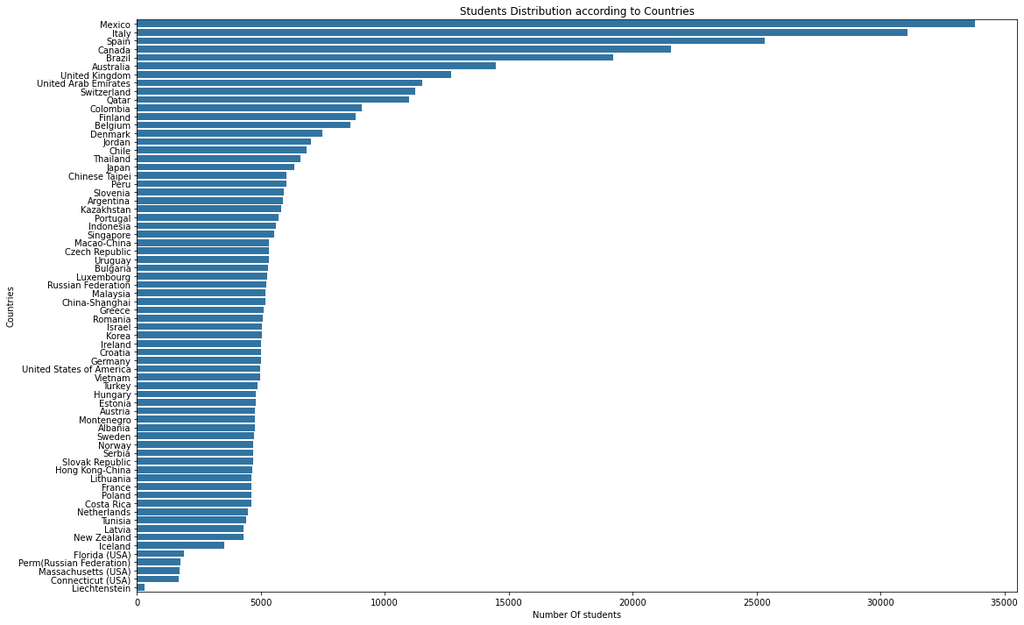

```python
cnt_count = student_new.CNT.value_counts()

plt.figure(figsize=[18,12])
cnt_title = cnt_count.index
sb.countplot(data = student_new, y = 'CNT', color = base_color, order=cnt_title)
plt.title('Students Distribution according to Countries')
plt.xlabel('Number Of students')
plt.ylabel('Countries')
```

# Observation 1

- From the above chart. we notice that Mexico has the highest number of students with 33806, followed by Italy with 31073,Spain with 25313 and Canada 21544 students.

# Question 2

- What is the economic, social and cultural status distribution of the students?

```python
#Index of economic, social and cultural status
student_new.ESCS.value_counts()
```

```
-0.42    1735
-0.20    1687
-0.82    1651
-0.14    1649
 0.05    1639
         ...
 2.79       1
 2.87       1
-5.62       1
-4.64       1
-5.11       1
Name: ESCS, Length: 784, dtype: int64
```

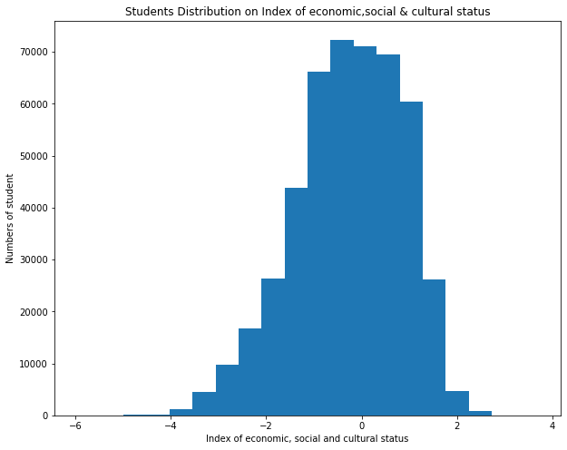

```python
plt.figure(figsize = [10,8])
bins = np.arange(0, student_new['ESCS'].max()+5,5)
plt.hist(data = student_new, x = 'ESCS' , bins = 20);
plt.title('Students Distribution on Index of economic,social & cultural status')
plt.xlabel('Index of economic, social and cultural status')
plt.ylabel('Numbers of student')
```

# Observation 2

- The students economic,social and cultural status ranges from a negative 4 to a positve 2. Alot of the students come from the middle class.

# Question 3

- What is the family structures of the students?

```python
#"Family Structure"
student_new.FAMSTRUC.value_counts()
```

```
2.0    360003
1.0     58264
3.0     10791
Name: FAMSTRUC, dtype: int64
```

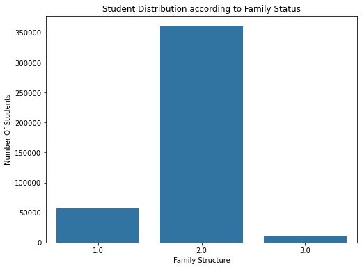

```python
#Plot of the family structures.
plt.figure(figsize = [8,6])
sb.countplot(data = student_new, x = 'FAMSTRUC', color = base_color)
plt.title('Student Distribution according to Family Status')
plt.xlabel('Family Structure')
plt.ylabel('Number Of Students')
```

# Observation 3

- From the above plot, we see that alot of the students come from a 2 family structure, over 350.000+.

# Question 4

- What is the highest educational level of parents?

```python
student_new.HISCED.value_counts()
```

```
ISCED 5A, 6          159942
ISCED 3A, ISCED 4    123304
ISCED 5B              74131
ISCED 2               51506
ISCED 3B, C           30469
ISCED 1               25284
None                   8455
Name: HISCED, dtype: int64
```

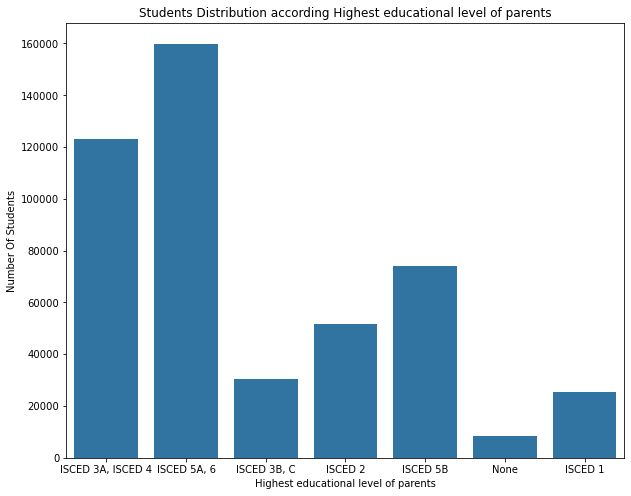

```python
#Plot of the Highest educational level of parents
plt.figure(figsize = [10,8])
sb.countplot(data = student_new, x = 'HISCED', color = base_color)
plt.title('Students Distribution according Highest educational level of parents')
plt.xlabel('Highest educational level of parents')
plt.ylabel('Number Of Students')
```

# Observation 4

- Alot of the student parents have a ISCED 5A,6 education level.

# Question 5

- What is the mean scores distribution of the three disciplines.

```python
#Mathematics Score
student_new.PV1MATH.value_counts()
```

```
444.1580    359
439.4843    354
452.7263    349
455.8420    346
458.1788    343
           ...
85.0678       1
244.5163      1
757.8361      1
82.6531       1
824.7468      1
Name: PV1MATH, Length: 7063, dtype: int64
```

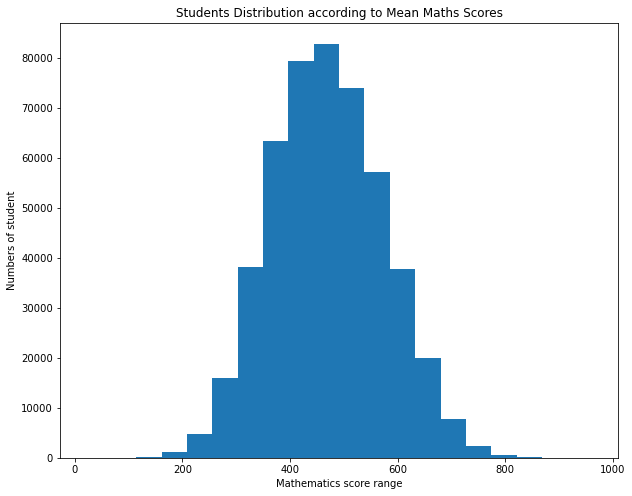

```python
plt.figure(figsize = [10,8])
bins = np.arange(0, student_new['PV1MATH'].max()+5,5)
plt.hist(data = student_new, x = 'PV1MATH' , bins = 20);
plt.title('Students Distribution according to Mean Maths Scores')
plt.xlabel('Mathematics score range')
plt.ylabel('Numbers of student')
```

```python
student_new.PV1READ.value_counts()
```

```
510.1099    355
483.1034    352
510.9042    350
492.6351    347
483.8977    345
           ...
637.6885      1
620.5984      1
223.0027      1
667.2802      1
672.9741      1
Name: PV1READ, Length: 11556, dtype: int64
```

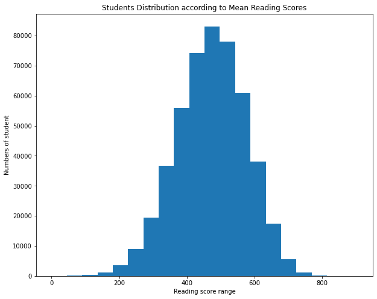

```python
plt.figure(figsize = [10,8])
bins = np.arange(0, student_new['PV1READ'].max()+5,5)
plt.hist(data = student_new, x = 'PV1READ' , bins = 20);
plt.title('Students Distribution according to Mean Reading Scores')
plt.xlabel('Reading score range')
plt.ylabel('Numbers of student')
```

```python
student_new.PV1SCIE.value_counts()
```

```
472.5289    753
484.6512    737
475.3264    736
444.5543    733
492.1112    732
           ...
234.9310      1
166.5796      1
195.6733      1
146.9041      1
691.2906      1
Name: PV1SCIE, Length: 6153, dtype: int64
```

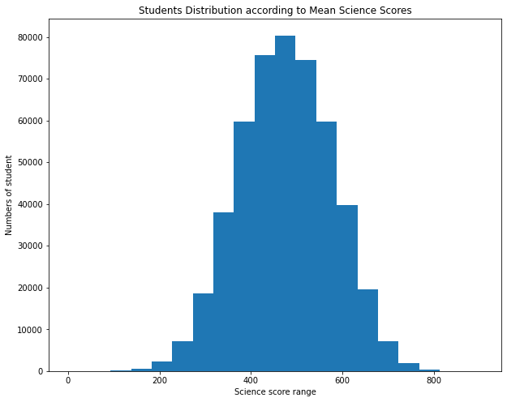

```python
plt.figure(figsize = [10,8])
bins = np.arange(0, student_new['PV1SCIE'].max()+5,5)
plt.hist(data = student_new, x = 'PV1SCIE' , bins = 20);
plt.title('Students Distribution according to Mean Science Scores')
plt.xlabel('Science score range')
plt.ylabel('Numbers of student')
```

# Observation 5

- We see that all score variables follow a normal mean distribution,with scores ranging from 200 - 800 points and from all 3 scores we can see that majority of the students have the mean score of 500 points.

# Question 6

- What is the OECD distribution of the countries?

```python
student_new.OECD.nunique()
```

```
2
```

```python
student_new.OECD.value_counts()
```

```
OECD        295416
Non-OECD    190074
Name: OECD, dtype: int64
```

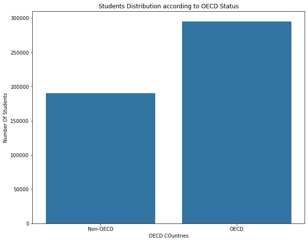

```python
#Plot of the OECD variables
plt.figure(figsize = [10,8])
sb.countplot(data = student_new, x = 'OECD', color = base_color)
plt.title('Students Distribution according to OECD Status')
plt.xlabel('OECD COuntries')
plt.ylabel('Number Of Students')
```

# Observation 6

- Student from OECD countries are higher than Non_OECD

# Question 7

- What is the gender distribution of the student?

```python
student_new.ST04Q01.value_counts()
```

```
Female    245064
Male      240426
Name: ST04Q01, dtype: int64
```

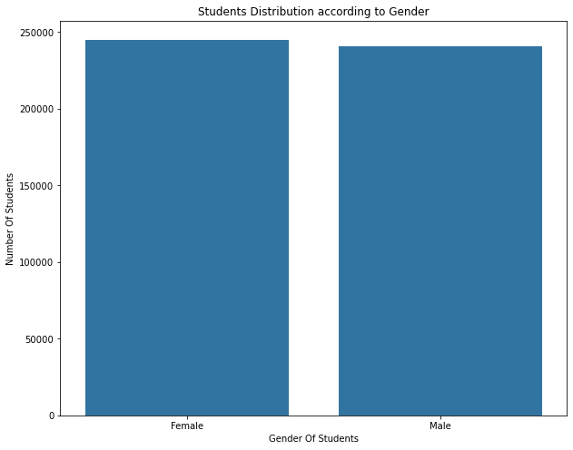

```python
# TO see the amount of the gender varaible.
plt.figure(figsize = [10,8])
sb.countplot(data = student_new, x = 'ST04Q01', color = base_color)
plt.title('Students Distribution according to Gender')
plt.xlabel('Gender Of Students')
plt.ylabel('Number Of Students')
```

# Observation 7

- The difference between the female and male students is really not too significant but there are more female students.

# Using the mean score variables, I will search for certain informations on performance in regards to gender, location,parents level of education,wealth etc.

# Question 8

- What is the gender distribution in regards to thier scores?

```python
def ploting (var_1,var_2,title):
    plt.figure(figsize=[8, 5])
    student_new.groupby(var_1).mean()[var_2].plot(kind='bar')
    plt.title(title)
    plt.xlabel('Gender')
    plt.ylabel('Mean Scores')
```

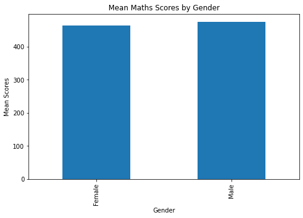

```python
#Ploting the mean maths scores by gender
ploting('ST04Q01','PV1MATH','Mean Maths Scores by Gender')
```

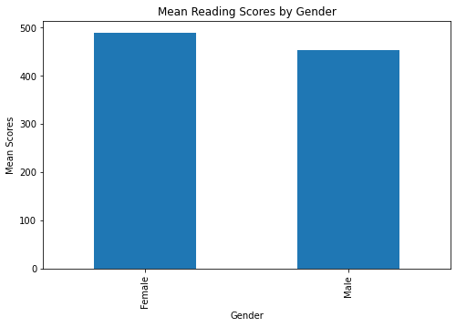

```python
#Ploting the mean reading scores by gender
ploting('ST04Q01','PV1READ','Mean Reading Scores by Gender')
```

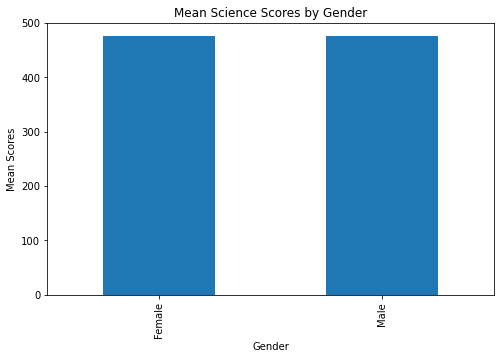

```python
#Ploting the mean science scores by gender
ploting('ST04Q01','PV1SCIE','Mean Science Scores by Gender')
```

# Observation 8

- When we examine the above bar charts, you will notice that,in maths boys did more than girls, in reading girls were better readers and in the science, there isnt much difference in their perfomance.

# Question 9

- What is the OECD status of the country involved in regards to thier scores?

```python
def ploting_1 (var_1,var_2,title):
    plt.figure(figsize=[8, 5])
    student_new.groupby(var_1).mean()[var_2].plot(kind='pie', startangle = 90, counterclock = False, autopct='%1.0f%%')
    plt.title(title)
    plt.xlabel('Students')
    plt.ylabel('Mean Scores')
```

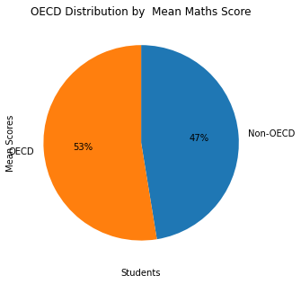

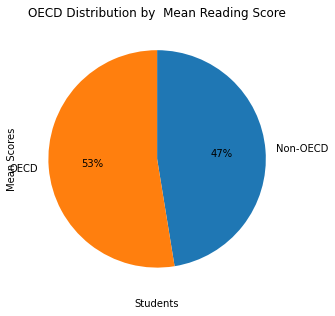

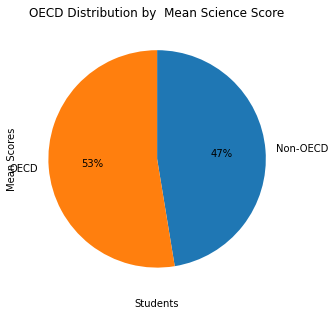

```python
ploting_1('OECD','PV1MATH','OECD Distribution by  Mean Maths Score')
ploting_1('OECD','PV1READ','OECD Distribution by  Mean Reading Score')
ploting_1('OECD','PV1SCIE','OECD Distribution by  Mean Science Score')
```

# Observation 9

- Looking at the above pie charts, you will notice that the OECD country performed better in all 3 ,ie mathematics,reading and science than the Non-OECD

# Question 10

- Whats the distribution of the countires in regards to thier scores?

```python
def ploting_2 (var_1,var_2,title):
    plt.figure(figsize=[15, 12])
    student_new.groupby(var_1).mean()[var_2].plot(kind='bar')
    plt.title(title)
    plt.xlabel('Countries')
    plt.ylabel('Mean Scores')
```

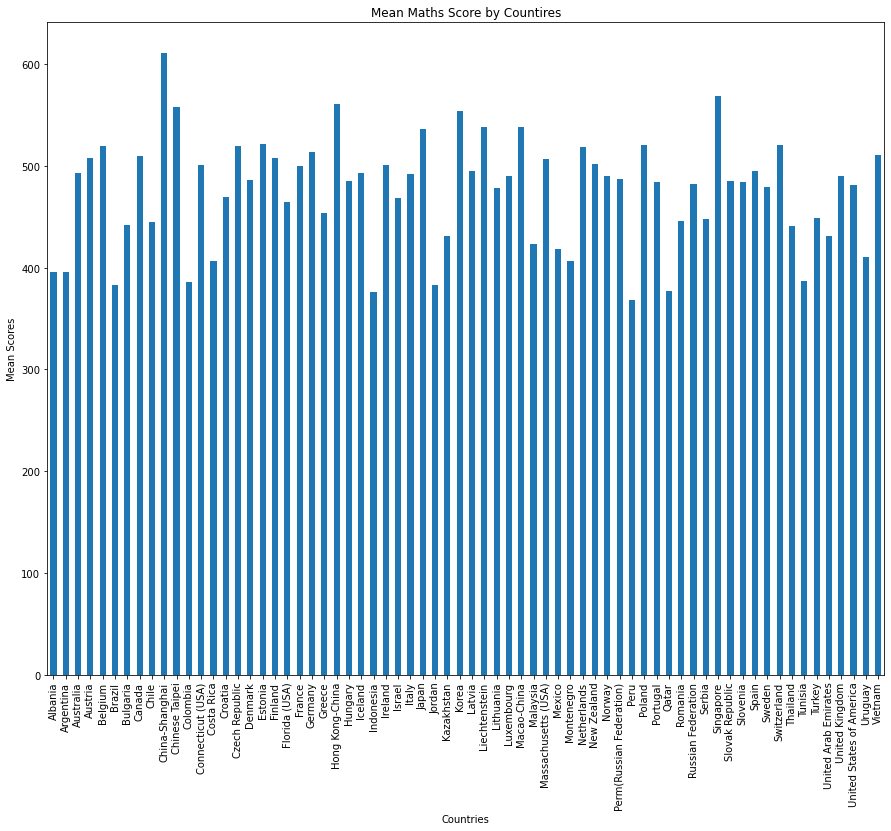

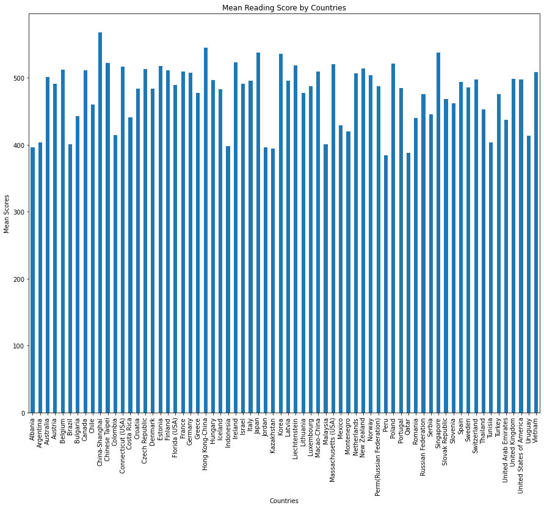

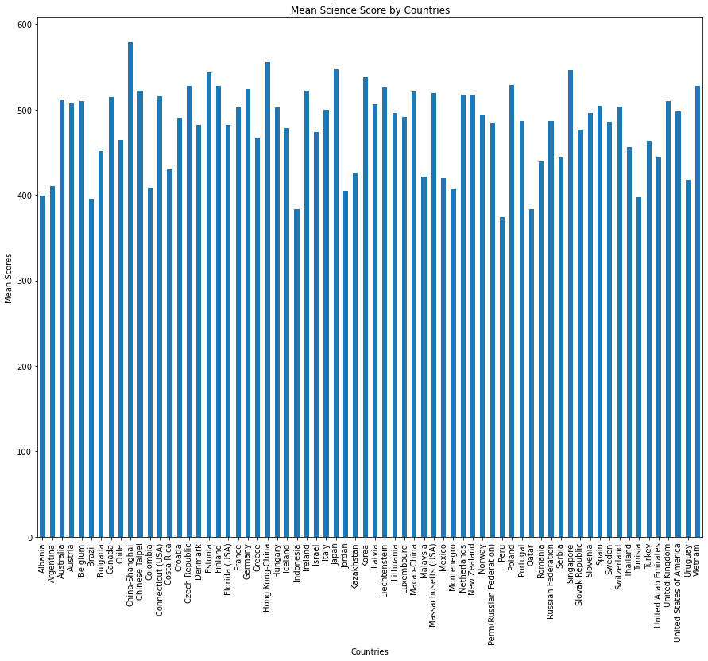

```python
ploting_2('CNT','PV1MATH','Mean Maths Score by Countires')
ploting_2('CNT','PV1READ','Mean Reading Score by Countries')
ploting_2('CNT','PV1SCIE','Mean Science Score by Countries')
```